# Evaluation of the Ebola Data and Statistics

## by Uchanma Adeola Igbokwe

## Introduction

> The source of this dataset is the World Health Organization (WHO). Contributions were made by HDX. It provides data for the total number of probable, confirmed and suspected Ebola cases and deaths in Guinea, Liberia, Sierra Leone, Nigeria, Senegal, Mali, Spain, the USA, the United Kingdom and Italy according to Ebola Data and Statistics. The date of the dataset is August 29, 2014 to March 23, 2016 and last updated on 10 November, 2019. The dataset contains approximately 17585 entries.

> Ebola virus disease (EVD) is a deadly disease with occasional outbreaks that occur mostly on the African continent. EVD most commonly affects people and nonhuman primates (such as monkeys, gorillas, and chimpanzees). It is caused by an infection with a group of viruses within the genus Ebolavirus(Centre for Disease Control[CDC], 2021).

## Preliminary Wrangling

```python
# import all packages and set plots to be embedded inline
import pandas as pd
import numpy as np
import matplotlib.pyplot as plt
%matplotlib inline
import seaborn as sb
sb.set_style('darkgrid')
```

> Load in your dataset and describe its properties through the questions below. Try and motivate your exploration goals through this section.

```python
#Load the dataset for analysis
df = pd.read_csv('ebola_data_db_format.csv', )
```

```python
#Preview dataset
df.head()
```

|  | Indicator | Country | Date | value |
| --- | --- | --- | --- | --- |
| 0 | Cumulative number of confirmed, probable and s... | Guinea | 2015-03-10 | 3285.0 |
| 1 | Cumulative number of confirmed Ebola cases | Guinea | 2015-03-10 | 2871.0 |
| 2 | Cumulative number of probable Ebola cases | Guinea | 2015-03-10 | 392.0 |
| 3 | Cumulative number of suspected Ebola cases | Guinea | 2015-03-10 | 22.0 |
| 4 | Cumulative number of confirmed, probable and s... | Guinea | 2015-03-10 | 2170.0 |

```python
# Check for duplicate data
df.duplicated().any()
```

```
False
```

```python
# Examining more rows of the dataset
df.sample(10)
```

|  | Indicator | Country | Date | value |
| --- | --- | --- | --- | --- |
| 15270 | Cumulative number of confirmed, probable and s... | Liberia | 2015-10-16 | 10666.0 |
| 3459 | Cumulative number of suspected Ebola cases | Spain | 2014-11-21 | 0.0 |
| 15412 | Cumulative number of probable Ebola cases | Liberia | 2015-10-22 | 1879.0 |
| 12376 | Cumulative number of confirmed Ebola cases | Italy | 2015-08-19 | 1.0 |
| 14226 | Cumulative number of probable Ebola cases | Spain | 2015-09-23 | 0.0 |
| 6167 | Cumulative number of suspected Ebola cases | United Kingdom | 2015-04-14 | 0.0 |
| 15645 | Cumulative number of confirmed, probable and s... | Guinea | 2015-10-27 | 3806.0 |
| 15425 | Cumulative number of confirmed Ebola cases | Sierra Leone | 2015-10-22 | 8704.0 |
| 12248 | Cumulative number of confirmed, probable and s... | Senegal | 2015-08-17 | 1.0 |
| 9370 | Cumulative number of suspected Ebola deaths | Senegal | 2015-06-22 | 0.0 |

```python
# Overview of indicator and country columns
print('Indicators include:', df.Indicator.unique())


print('Countries:', df.Country.unique())
```

```
Indicators include: ['Cumulative number of confirmed, probable and suspected Ebola cases'
 'Cumulative number of confirmed Ebola cases'
 'Cumulative number of probable Ebola cases'
 'Cumulative number of suspected Ebola cases'
 'Cumulative number of confirmed, probable and suspected Ebola deaths'
 'Cumulative number of confirmed Ebola deaths'
 'Cumulative number of probable Ebola deaths'
 'Cumulative number of suspected Ebola deaths'
 'Number of confirmed Ebola cases in the last 21 days'
 'Number of confirmed, probable and suspected Ebola cases in the last 21 days'
 'Number of probable Ebola cases in the last 21 days'
 'Number of confirmed Ebola cases in the last 7 days'
 'Number of probable Ebola cases in the last 7 days'
 'Number of suspected Ebola cases in the last 7 days'
 'Number of confirmed, probable and suspected Ebola cases in the last 7 days'
 'Proportion of confirmed Ebola cases that are from the last 7 days'
 'Proportion of probable Ebola cases that are from the last 7 days'
 'Proportion of suspected Ebola cases that are from the last 7 days'
 'Proportion of confirmed, probable and suspected Ebola cases that are from the last 7 days'
 'Number of suspected Ebola cases in the last 21 days'
 'Proportion of confirmed Ebola cases that are from the last 21 days'
 'Proportion of probable Ebola cases that are from the last 21 days'
 'Proportion of suspected Ebola cases that are from the last 21 days'
 'Proportion of confirmed, probable and suspected Ebola cases that are from the last 21 days'
 'Case fatality rate (CFR) of confirmed Ebola cases'
 'Case fatality rate (CFR) of probable Ebola cases'
 'Case fatality rate (CFR) of suspected Ebola cases'
 'Case fatality rate (CFR) of confirmed, probable and suspected Ebola cases'
 'Number of confirmed Ebola deaths in the last 21 days'
 'Number of probable Ebola deaths in the last 21 days'
 'Number of suspected Ebola deaths in the last 21 days'
 'Number of confirmed, probable and suspected Ebola deaths in the last 21 days'
 'Proportion of confirmed Ebola deaths that are from the last 21 days'
 'Proportion of probable Ebola deaths that are from the last 21 days'
 'Proportion of suspected Ebola deaths that are from the last 21 days'
 'Proportion of confirmed, probable and suspected Ebola deaths that are from the last 21 days']
Countries: ['Guinea' 'Liberia' 'Sierra Leone' 'United Kingdom' 'Mali' 'Nigeria'
 'Senegal' 'Spain' 'United States of America' 'Italy' 'Liberia 2'
 'Guinea 2']
```

### What is the structure of your dataset?

> There are 36 unique indicators in this dataset. The dataset is in the long format, meaning that variables/indicators are entered as rows. There are 10 countries with values for each indicator listed and on dates between 29th August 2014 to 29th December 2015. And other observations for 2016.

> Analysis cannot be carried out on the dataset as it is, therefore, data cleaning needs to be done.

### What is/are the main feature(s) of interest in your dataset?

> I am interested in examining the 'Cumulative number of confirmed Ebola deaths', the 'Cumulative number of probable Ebola cases' and the Case fatality rate (CFR) of confirmed Ebola cases.

### What features in the dataset do you think will help support your investigation into your feature(s) of interest?

> My hypothesis is that as the number of deaths increases, the more confirmed cases of Ebola. To get this, I will examine how the column variables "Cumulative number of confirmed Ebola cases" relates to the variable "Cumulative number of confirmed Ebola deaths".

> I would also like to see the distribution of confirmed Ebola deaths in the various countries.

> I would also examine the trends in confirmed Ebola deaths as the date progressed. This would help me know whether confirmed deaths increased or decreased as the outbreak progressed. This might be an indication of how well the cases were being handled in each country.

> How does the cumulative number of confirmed Ebola cases compare to the cumulative number of probable Ebola cases?

> Examine how the case fatality rates compare in the countries for the period of outbreak.

```python
# Taking steps to clean dataset
# Make a copy of the dataset before cleaning.
df = df.copy()


# Change data format from long to wide. This is in line with the tidy data requirement that states that each variable must be a column.
ebola_df = df.pivot(index = ['Country', 'Date'], columns = 'Indicator', values = 'value')
```

```python
# Confirm to see that variables are now columns.
print('Shape of dataset:', ebola_df.shape)

ebola_df.sample()
```

```
Shape of dataset: (2485, 36)
```

| Country | Indicator Date | Case fatality rate (CFR) of confirmed Ebola cases | Case fatality rate (CFR) of confirmed, probable and suspected Ebola cases | Case fatality rate (CFR) of probable Ebola cases | Case fatality rate (CFR) of suspected Ebola cases | Cumulative number of confirmed Ebola cases | Cumulative number of confirmed Ebola deaths | Cumulative number of confirmed, probable and suspected Ebola cases | Cumulative number of confirmed, probable and suspected Ebola deaths | Cumulative number of probable Ebola cases | Cumulative number of probable Ebola deaths | ... | Proportion of confirmed Ebola deaths that are from the last 21 days | Proportion of confirmed, probable and suspected Ebola cases that are from the last 21 days | Proportion of confirmed, probable and suspected Ebola cases that are from the last 7 days | Proportion of confirmed, probable and suspected Ebola deaths that are from the last 21 days | Proportion of probable Ebola cases that are from the last 21 days | Proportion of probable Ebola cases that are from the last 7 days | Proportion of probable Ebola deaths that are from the last 21 days | Proportion of suspected Ebola cases that are from the last 21 days | Proportion of suspected Ebola cases that are from the last 7 days | Proportion of suspected Ebola deaths that are from the last 21 days |
| --- | --- | --- | --- | --- | --- | --- | --- | --- | --- | --- | --- | --- | --- | --- | --- | --- | --- | --- | --- | --- | --- | --- |
| Sierra Leone | 2015-11-06 | NaN | NaN | NaN | NaN | 8704.0 | 3589.0 | 14109.0 | 3955.0 | 287.0 | 208.0 | ... | NaN | NaN | NaN | NaN | NaN | NaN | NaN | NaN | NaN | NaN |

1 rows × 36 columns

```python
# Change index column
ebola_df.reset_index(inplace= True)

#Check data types of columns and completeness of each.
ebola_df.info()
```

```
<class 'pandas.core.frame.DataFrame'>
RangeIndex: 2485 entries, 0 to 2484
Data columns (total 38 columns):
 #   Column                                                                                       Non-Null Count  Dtype
---  ------                                                                                       --------------  -----
 0   Country                                                                                      2485 non-null   object
 1   Date                                                                                         2485 non-null   object
 2   Case fatality rate (CFR) of confirmed Ebola cases                                            19 non-null     float64
 3   Case fatality rate (CFR) of confirmed, probable and suspected Ebola cases                    19 non-null     float64
 4   Case fatality rate (CFR) of probable Ebola cases                                             18 non-null     float64
 5   Case fatality rate (CFR) of suspected Ebola cases                                            18 non-null     float64
 6   Cumulative number of confirmed Ebola cases                                                   2484 non-null   float64
 7   Cumulative number of confirmed Ebola deaths                                                  1648 non-null   float64
 8   Cumulative number of confirmed, probable and suspected Ebola cases                           2477 non-null   float64
 9   Cumulative number of confirmed, probable and suspected Ebola deaths                          2485 non-null   float64
```

[output cut: 30 more lines]

```python
# Check number of null values in the dataset
ebola_df.isnull().sum().to_frame().T
```

| Indicator | Country | Date | Case fatality rate (CFR) of confirmed Ebola cases | Case fatality rate (CFR) of confirmed, probable and suspected Ebola cases | Case fatality rate (CFR) of probable Ebola cases | Case fatality rate (CFR) of suspected Ebola cases | Cumulative number of confirmed Ebola cases | Cumulative number of confirmed Ebola deaths | Cumulative number of confirmed, probable and suspected Ebola cases | Cumulative number of confirmed, probable and suspected Ebola deaths | ... | Proportion of confirmed Ebola deaths that are from the last 21 days | Proportion of confirmed, probable and suspected Ebola cases that are from the last 21 days | Proportion of confirmed, probable and suspected Ebola cases that are from the last 7 days | Proportion of confirmed, probable and suspected Ebola deaths that are from the last 21 days | Proportion of probable Ebola cases that are from the last 21 days | Proportion of probable Ebola cases that are from the last 7 days | Proportion of probable Ebola deaths that are from the last 21 days | Proportion of suspected Ebola cases that are from the last 21 days | Proportion of suspected Ebola cases that are from the last 7 days | Proportion of suspected Ebola deaths that are from the last 21 days |
| --- | --- | --- | --- | --- | --- | --- | --- | --- | --- | --- | --- | --- | --- | --- | --- | --- | --- | --- | --- | --- | --- |
| 0 | 0 | 0 | 2466 | 2466 | 2467 | 2467 | 1 | 837 | 8 | 0 | ... | 2472 | 2444 | 2479 | 2472 | 2445 | 2479 | 2473 | 2446 | 2479 | 2475 |

1 rows × 38 columns

```python
#Showing percentage of null values in each column
ebola_df.isna().sum()/(len(ebola_df)) * 100
```

```
Indicator
Country                                                                                         0.000000
Date                                                                                            0.000000
Case fatality rate (CFR) of confirmed Ebola cases                                              99.235412
Case fatality rate (CFR) of confirmed, probable and suspected Ebola cases                      99.235412
Case fatality rate (CFR) of probable Ebola cases                                               99.275654
Case fatality rate (CFR) of suspected Ebola cases                                              99.275654
Cumulative number of confirmed Ebola cases                                                      0.040241
Cumulative number of confirmed Ebola deaths                                                    33.682093
Cumulative number of confirmed, probable and suspected Ebola cases                              0.321932
Cumulative number of confirmed, probable and suspected Ebola deaths                             0.000000
Cumulative number of probable Ebola cases                                                       1.971831
Cumulative number of probable Ebola deaths                                                     38.591549
Cumulative number of suspected Ebola cases                                                      4.788732
Cumulative number of suspected Ebola deaths                                                    47.364185
Number of confirmed Ebola cases in the last 21 days                                            92.354125
Number of confirmed Ebola cases in the last 7 days                                             99.758551
Number of confirmed Ebola deaths in the last 21 days                                           99.436620
Number of confirmed, probable and suspected Ebola cases in the last 21 days                    92.354125
Number of confirmed, probable and suspected Ebola cases in the last 7 days                     99.758551
Number of confirmed, probable and suspected Ebola deaths in the last 21 days                   99.436620
Number of probable Ebola cases in the last 21 days                                             97.907445
Number of probable Ebola cases in the last 7 days                                              99.758551
Number of probable Ebola deaths in the last 21 days                                            99.476861
Number of suspected Ebola cases in the last 21 days                                            98.430584
Number of suspected Ebola cases in the last 7 days                                             99.758551
Number of suspected Ebola deaths in the last 21 days                                           99.476861
Proportion of confirmed Ebola cases that are from the last 21 days                             98.390342
Proportion of confirmed Ebola cases that are from the last 7 days                              99.758551
Proportion of confirmed Ebola deaths that are from the last 21 days                            99.476861
Proportion of confirmed, probable and suspected Ebola cases that are from the last 21 days     98.350101
Proportion of confirmed, probable and suspected Ebola cases that are from the last 7 days      99.758551
Proportion of confirmed, probable and suspected Ebola deaths that are from the last 21 days    99.476861
Proportion of probable Ebola cases that are from the last 21 days                              98.390342
Proportion of probable Ebola cases that are from the last 7 days                               99.758551
Proportion of probable Ebola deaths that are from the last 21 days                             99.517103
Proportion of suspected Ebola cases that are from the last 21 days                             98.430584
Proportion of suspected Ebola cases that are from the last 7 days                              99.758551
Proportion of suspected Ebola deaths that are from the last 21 days                            99.597586
dtype: float64
```

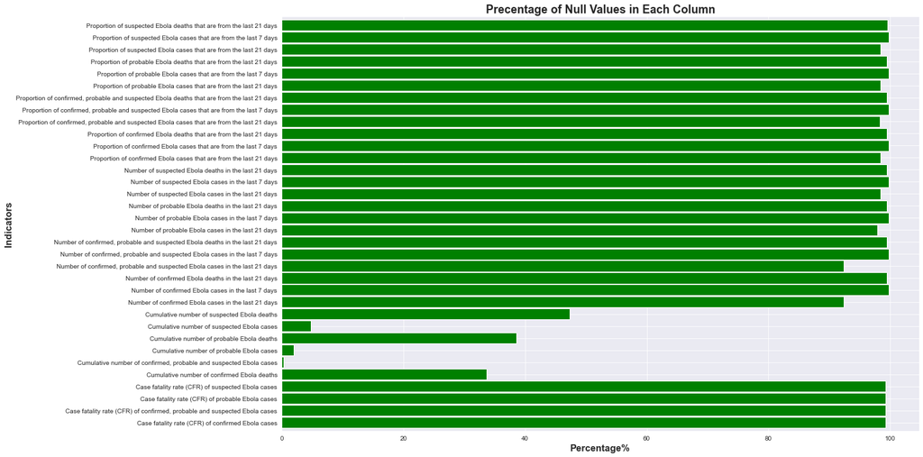

```python
#Dislay number of nulls in each column using a chart

#Removing columns without nulls
ebola_dfnull = ebola_df.drop(['Date', 'Country', 'Cumulative number of confirmed Ebola cases', 'Cumulative number of confirmed, probable and suspected Ebola deaths'], axis= 1).isna().sum()


#Plot chart
(ebola_dfnull/(len(ebola_df)) * 100).plot.barh(color = ['g'], width = 0.9, figsize = [18,12]);
plt.title('Precentage of Null Values in Each Column', fontsize = 18, weight = "bold" );
plt.xlabel('Percentage%', fontsize=15, weight = "bold")
plt.ylabel('Indicators', fontsize=15, weight = "bold")
```

```python
# Selecting and renaming columns necessary for analysis.
ebola_df = ebola_df[['Date', 'Country', 'Cumulative number of confirmed Ebola cases',
                    'Cumulative number of suspected Ebola cases',
                     'Cumulative number of probable Ebola cases',
                     'Cumulative number of confirmed, probable and suspected Ebola cases',
                     'Cumulative number of confirmed Ebola deaths',
                     'Cumulative number of suspected Ebola deaths',
                     'Cumulative number of probable Ebola deaths',
                     'Cumulative number of confirmed, probable and suspected Ebola deaths']]

# Rename columns
ebola_df.columns = ['date', 'country', 'total_confirmed_cases',
                    'total_suspected_cases',
                    'total_probable_cases',
                    'total_confirmed_probable_suspected_cases',
                    'total_confirmed_deaths',
                    'total_suspected_deaths',
                    'total_probable_deaths',
                    'total_confirmed_probable_suspected_deaths']
```

```python
# Confirm selection and renaming.
list(enumerate(ebola_df.columns))
```

```
[(0, 'date'),
 (1, 'country'),
 (2, 'total_confirmed_cases'),
 (3, 'total_suspected_cases'),
 (4, 'total_probable_cases'),
 (5, 'total_confirmed_probable_suspected_cases'),
 (6, 'total_confirmed_deaths'),
 (7, 'total_suspected_deaths'),
 (8, 'total_probable_deaths'),
 (9, 'total_confirmed_probable_suspected_deaths')]
```

```python
#Converting datatypes of columns

#Convert dtype for date column
ebola_df['date'] = pd.to_datetime(ebola_df['date'])

#Converting all other columns from float to integer.
c = ebola_df.select_dtypes(np.number)
ebola_df[c.columns]= c.round().astype('Int64')
```

```python
# Confirming all columns now have the correct datatype.
ebola_df.dtypes
```

```
date                                         datetime64[ns]
country                                              object
total_confirmed_cases                                 Int64
total_suspected_cases                                 Int64
total_probable_cases                                  Int64
total_confirmed_probable_suspected_cases              Int64
total_confirmed_deaths                                Int64
total_suspected_deaths                                Int64
total_probable_deaths                                 Int64
total_confirmed_probable_suspected_deaths             Int64
dtype: object
```

```python
# Create columns with year and month
ebola_df['year']= ebola_df.date.dt.year
ebola_df['month_name'] = ebola_df.date.dt.month_name()
ebola_df['monthyear'] = ebola_df['month_name'] + ' ' + ebola_df['year'].map(str)
```

```python
# Confirm creation of year, month and monthyear columns
ebola_df.head(2)
```

|  | date | country | total_confirmed_cases | total_suspected_cases | total_probable_cases | total_confirmed_probable_suspected_cases | total_confirmed_deaths | total_suspected_deaths | total_probable_deaths | total_confirmed_probable_suspected_deaths | year | month_name | monthyear |
| --- | --- | --- | --- | --- | --- | --- | --- | --- | --- | --- | --- | --- | --- |
| 0 | 2014-08-29 | Guinea | 482 | 25 | 141 | 648 | 287 | 2 | 141 | 430 | 2014 | August | August 2014 |
| 1 | 2014-09-05 | Guinea | 604 | 56 | 152 | 812 | 362 | 3 | 152 | 517 | 2014 | September | September 2014 |

```python
# Examine country names and number of ccurrence in the country column
ebola_df.country.value_counts()
```

```
Guinea                      259
Liberia                     259
Sierra Leone                259
Nigeria                     255
Senegal                     254
United States of America    245
Mali                        243
Spain                       243
United Kingdom              221
Italy                       141
Liberia 2                   105
Guinea 2                      1
Name: country, dtype: int64
```

```python
#Check number of occurrence of Guinea 2
ebola_df.loc[ebola_df['country'] == 'Guinea 2']
```

|  | date | country | total_confirmed_cases | total_suspected_cases | total_probable_cases | total_confirmed_probable_suspected_cases | total_confirmed_deaths | total_suspected_deaths | total_probable_deaths | total_confirmed_probable_suspected_deaths | year | month_name | monthyear |
| --- | --- | --- | --- | --- | --- | --- | --- | --- | --- | --- | --- | --- | --- |
| 259 | 2016-03-23 | Guinea 2 | 2 | 0 | 3 | 5 | 1 | <NA> | 3 | 4 | 2016 | March | March 2016 |

```python
#Check number of occurrence of Liberia 2
ebola_df.loc[ebola_df['country'] == 'Liberia 2']
```

|  | date | country | total_confirmed_cases | total_suspected_cases | total_probable_cases | total_confirmed_probable_suspected_cases | total_confirmed_deaths | total_suspected_deaths | total_probable_deaths | total_confirmed_probable_suspected_deaths | year | month_name | monthyear |
| --- | --- | --- | --- | --- | --- | --- | --- | --- | --- | --- | --- | --- | --- |
| 660 | 2015-07-03 | Liberia 2 | 3 | 37 | 0 | 40 | 1 | 4 | 0 | 5 | 2015 | July | July 2015 |
| 661 | 2015-07-06 | Liberia 2 | 3 | <NA> | 1 | 4 | 1 | <NA> | <NA> | 1 | 2015 | July | July 2015 |
| 662 | 2015-07-07 | Liberia 2 | 3 | <NA> | 1 | 4 | 1 | <NA> | <NA> | 1 | 2015 | July | July 2015 |
| 663 | 2015-07-08 | Liberia 2 | 3 | <NA> | 1 | 4 | 1 | <NA> | <NA> | 1 | 2015 | July | July 2015 |
| 664 | 2015-07-09 | Liberia 2 | 5 | <NA> | 1 | 6 | 1 | <NA> | <NA> | 1 | 2015 | July | July 2015 |
| ... | ... | ... | ... | ... | ... | ... | ... | ... | ... | ... | ... | ... | ... |
| 760 | 2015-12-17 | Liberia 2 | 9 | <NA> | <NA> | 9 | 3 | <NA> | <NA> | 3 | 2015 | December | December 2015 |
| 761 | 2015-12-22 | Liberia 2 | 9 | <NA> | <NA> | 9 | 3 | <NA> | <NA> | 3 | 2015 | December | December 2015 |
| 762 | 2015-12-23 | Liberia 2 | 9 | <NA> | <NA> | 9 | 3 | <NA> | <NA> | 3 | 2015 | December | December 2015 |
| 763 | 2015-12-29 | Liberia 2 | 9 | <NA> | <NA> | 9 | 3 | <NA> | <NA> | 3 | 2015 | December | December 2015 |
| 764 | 2016-03-23 | Liberia 2 | 9 | <NA> | <NA> | 9 | 3 | <NA> | <NA> | 3 | 2016 | March | March 2016 |

105 rows × 13 columns

```python
#Make country names uniform in the dataframe
ebola_df['country'] = ebola_df['country'].str.replace('Guinea 2', 'Guinea')

ebola_df['country'] = ebola_df['country'].str.replace('Liberia 2', 'Liberia')
```

```python
#Confirm changes in country name
ebola_df.country.unique()
```

```
array(['Guinea', 'Italy', 'Liberia', 'Mali', 'Nigeria', 'Senegal',
       'Sierra Leone', 'Spain', 'United Kingdom',
       'United States of America'], dtype=object)
```

```python
#Create new column for case fatality rate of confirmed cases.
ebola_df['case_fatality_rate'] = ((ebola_df['total_confirmed_deaths'] / ebola_df['total_confirmed_cases']) * 100).round(1)
```

```python
# Overview of one of the main features of interest
print(ebola_df['total_confirmed_deaths'].describe())

#Changing percentiles
perc = [.20, .40, .60, .80]
ebola_df['total_confirmed_deaths'].describe(percentiles= perc).to_frame().T
```

```
count    1648.000000
mean      781.662015
std      1258.113098
min         0.000000
25%         0.000000
50%         2.000000
75%      1760.750000
max      3858.000000
Name: total_confirmed_deaths, dtype: float64
```

|  | count | mean | std | min | 20% | 40% | 50% | 60% | 80% | max |
| --- | --- | --- | --- | --- | --- | --- | --- | --- | --- | --- |
| total_confirmed_deaths | 1648.0 | 781.662015 | 1258.113098 | 0.0 | 0.0 | 1.0 | 2.0 | 7.0 | 2056.0 | 3858.0 |

```python
#Create categories for grouping the total number of deaths in each country.
cat = ebola_df.describe(percentiles= perc).total_confirmed_deaths.loc[['50%', '60%', '80%', 'max']] #changed percentiles to achieve greater accuracy in grouping.

#Bin egdes that will be used for categorizing
bin_edges = cat.values

#labels for the categories of ebola deaths by number
bin_names = ['low', 'high', 'very_high']

#creates category column
ebola_df['total_death_category'] = pd.cut(ebola_df['total_confirmed_deaths'], bin_edges, labels=bin_names)
```

```python
#confirming creation of category column
ebola_df.sample(3)
```

|  | date | country | total_confirmed_cases | total_suspected_cases | total_probable_cases | total_confirmed_probable_suspected_cases | total_confirmed_deaths | total_suspected_deaths | total_probable_deaths | total_confirmed_probable_suspected_deaths | year | month_name | monthyear | case_fatality_rate | total_death_category |
| --- | --- | --- | --- | --- | --- | --- | --- | --- | --- | --- | --- | --- | --- | --- | --- |
| 108 | 2015-04-30 | Guinea | 3159 | 7 | 415 | 3581 | 1966 | <NA> | 415 | 2381 | 2015 | April | April 2015 | 62.2 | high |
| 159 | 2015-07-10 | Guinea | 3293 | 8 | 450 | 3751 | 2055 | <NA> | 450 | 2505 | 2015 | July | July 2015 | 62.4 | high |
| 632 | 2015-10-26 | Liberia | 3151 | 5636 | 1879 | 10666 | <NA> | <NA> | <NA> | 4806 | 2015 | October | October 2015 | <NA> | NaN |

```python
# cOnfirm that all columns have the right dtype
ebola_df.dtypes
```

```
date                                         datetime64[ns]
country                                              object
total_confirmed_cases                                 Int64
total_suspected_cases                                 Int64
total_probable_cases                                  Int64
total_confirmed_probable_suspected_cases              Int64
total_confirmed_deaths                                Int64
total_suspected_deaths                                Int64
total_probable_deaths                                 Int64
total_confirmed_probable_suspected_deaths             Int64
year                                                  int64
month_name                                           object
monthyear                                            object
case_fatality_rate                                  Float64
total_death_category                               category
dtype: object
```

```python
# Overview of the description of numeric variables
ebola_df.describe(include = np.number)
```

|  | total_confirmed_cases | total_suspected_cases | total_probable_cases | total_confirmed_probable_suspected_cases | total_confirmed_deaths | total_suspected_deaths | total_probable_deaths | total_confirmed_probable_suspected_deaths | year | case_fatality_rate |
| --- | --- | --- | --- | --- | --- | --- | --- | --- | --- | --- |
| count | 2484.000000 | 2366.000000 | 2436.000000 | 2477.000000 | 1648.000000 | 1308.000000 | 1526.000000 | 2485.000000 | 2485.000000 | 1648.000000 |
| mean | 1436.616345 | 891.841505 | 263.733580 | 2553.678644 | 781.662015 | 32.899083 | 104.535387 | 1028.347686 | 2014.898189 | 28.729976 |
| std | 2574.200797 | 1828.699240 | 561.483886 | 4427.118148 | 1258.113098 | 73.166362 | 161.420208 | 1656.064372 | 0.318032 | 23.145926 |
| min | 1.000000 | 0.000000 | 0.000000 | 0.000000 | 0.000000 | 0.000000 | 0.000000 | 0.000000 | 2014.000000 | 0.000000 |
| 25% | 1.000000 | 0.000000 | 0.000000 | 1.000000 | 0.000000 | 0.000000 | 0.000000 | 0.000000 | 2015.000000 | 0.000000 |
| 50% | 7.000000 | 0.000000 | 1.000000 | 8.000000 | 2.000000 | 0.000000 | 1.000000 | 6.000000 | 2015.000000 | 33.300000 |
| 75% | 3118.000000 | 17.000000 | 287.000000 | 3657.000000 | 1760.750000 | 0.000000 | 208.000000 | 2386.000000 | 2015.000000 | 41.200000 |
| max | 8704.000000 | 5636.000000 | 2106.000000 | 14122.000000 | 3858.000000 | 661.000000 | 803.000000 | 4806.000000 | 2016.000000 | 128.600000 |

```python
# Save cleaned dataset to a csv file
ebola_df.to_csv('ebola_data_clean.csv', index= False)
```

```python
#Load cleaned dataset for analysis
ebola_df = pd.read_csv('ebola_data_clean.csv')
```

## Univariate Exploration

```python
#plotting histograms.
def myhist(ebola_df, xvar, bins):

    # A simple function created to avoid code repetition. It is to be used in plotting histograms of various movie properties within this notebook.
    #inputs : variables to be plotted
    #outputs: scatter plots of dependent variables against independent variable.

    #Plots
    plt.figure(figsize =(18, 7))
    sb.histplot(data= ebola_df, x=xvar, color = 'green', bins= bins);

    #Formats chart titles and labels
    #Tidy labels
    xvar = xvar.replace("_"," ") #replace _ with a space

    #Formats x-axis
    plt.xlabel(xvar.title(), fontsize=15)

    #Formats y-axis
    plt.ylabel('Frequency', fontsize=15)

    #Adds title to the top of histogram
    plt.title(f'Histogram of Ebola {xvar}'.title(), fontsize=18, weight="bold")
```

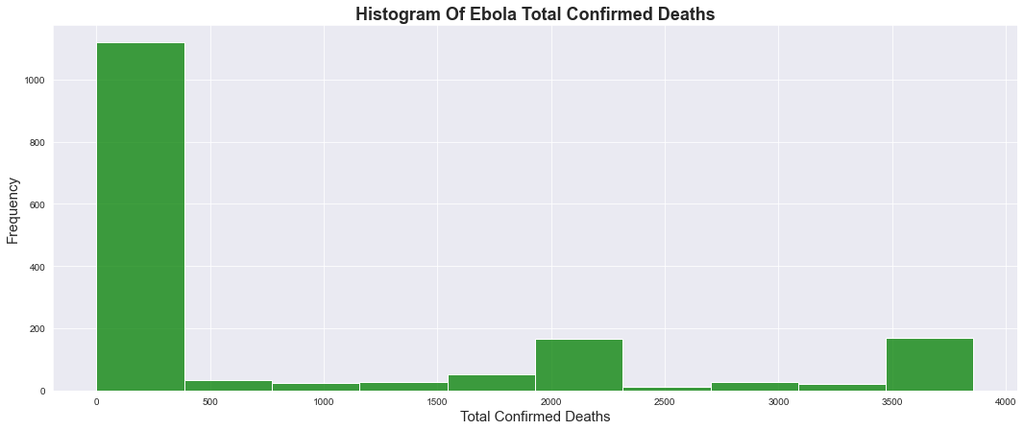

```python
# What is the distribution of the variable 'total confirmed deaths'
myhist(ebola_df, 'total_confirmed_deaths', bins= 10)
```

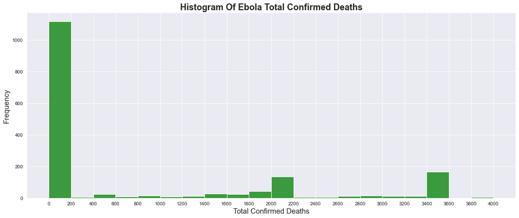

```python
#Exploring the variable 'total confirmed deaths' further.
bins = np.arange(0, ebola_df['total_confirmed_deaths'].max()+200, 200)
myhist(ebola_df, 'total_confirmed_deaths', bins = bins) #bin sizes changed using descriptive statistics
plt.xticks(bins);
```

It is important to note that this column contains some missing values, therefore, we can't conclude that the distribution would remain the same if there weren't missing values.

```python
#Exploring the value gap noticed above further.
greater_d= ebola_df.loc[ebola_df['total_confirmed_deaths'] > 3600]

greater_d
```

|  | date | country | total_confirmed_cases | total_suspected_cases | total_probable_cases | total_confirmed_probable_suspected_cases | total_confirmed_deaths | total_suspected_deaths | total_probable_deaths | total_confirmed_probable_suspected_deaths | year | month_name | monthyear | case_fatality_rate | total_death_category |
| --- | --- | --- | --- | --- | --- | --- | --- | --- | --- | --- | --- | --- | --- | --- | --- |
| 465 | 2015-02-10 | Liberia | 3146.0 | 3862.0 | 1873.0 | 8881.0 | 3826.0 | NaN | NaN | 3826 | 2015 | February | February 2015 | 121.6 | very_high |
| 466 | 2015-02-11 | Liberia | 3146.0 | 3862.0 | 1873.0 | 8881.0 | 3826.0 | NaN | NaN | 3826 | 2015 | February | February 2015 | 121.6 | very_high |
| 467 | 2015-02-12 | Liberia | 3146.0 | 3862.0 | 1873.0 | 8881.0 | 3826.0 | NaN | NaN | 3826 | 2015 | February | February 2015 | 121.6 | very_high |
| 468 | 2015-02-13 | Liberia | 3147.0 | 3908.0 | 1876.0 | 8931.0 | 3858.0 | NaN | NaN | 3858 | 2015 | February | February 2015 | 122.6 | very_high |

From the table above, we can see there are four rows with confirmed death values higher than 3600. And all occurrences are in Liberia in 2015.

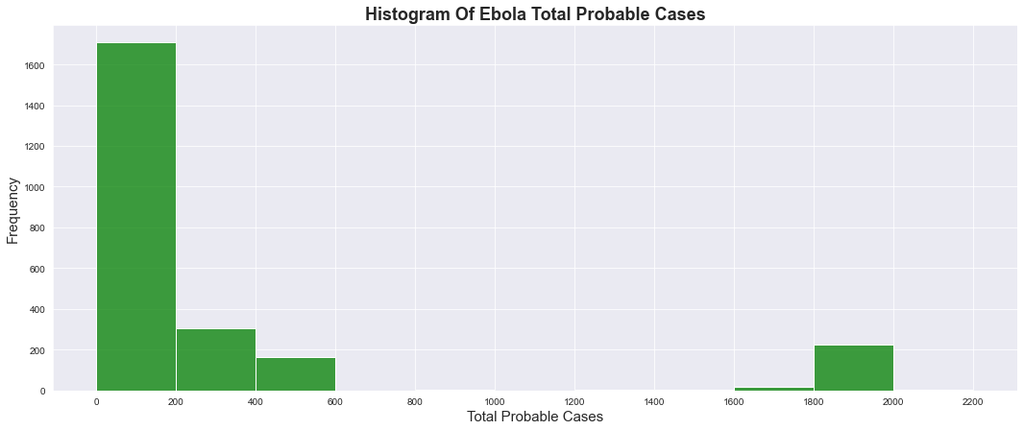

```python
# Second feature
# What is the distribution of total_probable_cases?
bins = np.arange(0, ebola_df['total_probable_cases'].max()+200, 200)
myhist(ebola_df, 'total_probable_cases', bins = bins) #bin sizes changed using descriptive statistics
plt.xticks(bins);
```

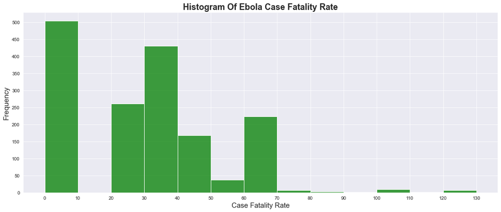

```python
# What is the distribution of the case fatality rate of confirmed cases?
bins = np.arange(0, ebola_df["case_fatality_rate"].max() + 10, 10)
myhist(ebola_df, "case_fatality_rate", bins = bins) #bin sizes changed using descriptive statistics
plt.xticks(bins);
plt.yticks(np.arange(0, 500 + 50, 50));
```

The case fatality rate histogram has right tailed and has two high peaks, one between 0-10 and the second at 30-40. The other bars contain a substantial number of values except from 70 and above. This distribution is bimodal. However, for case fatality rate, the desired value is one that occurs at the lower interval. This is because it is a measure of disease severity.

**Next, exploring other supporting variables.**

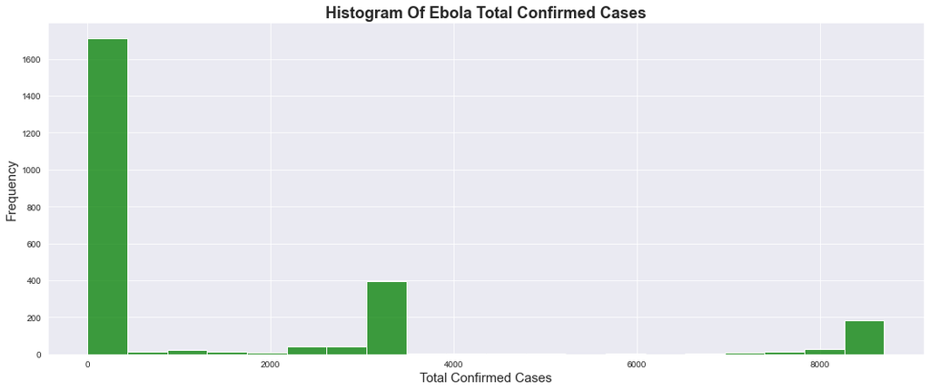

```python
# What is the distribution of confirmed cases in the dataset.
myhist(ebola_df, 'total_confirmed_cases', bins = 20)
```

Going by the above distribution, the most number of confirmed cases falls between the values '0 - 500 ' axis. There is a long stretch where there appears to be no values. This needs to be investigated further by adjusting bin sizes.

```python
#Viweing the descriptive statistics of the number of confirmed cases column
ebola_df['total_confirmed_cases'].describe().to_frame().T
```

|  | count | mean | std | min | 25% | 50% | 75% | max |
| --- | --- | --- | --- | --- | --- | --- | --- | --- |
| total_confirmed_cases | 2484.0 | 1436.616345 | 2574.200797 | 1.0 | 1.0 | 7.0 | 3118.0 | 8704.0 |

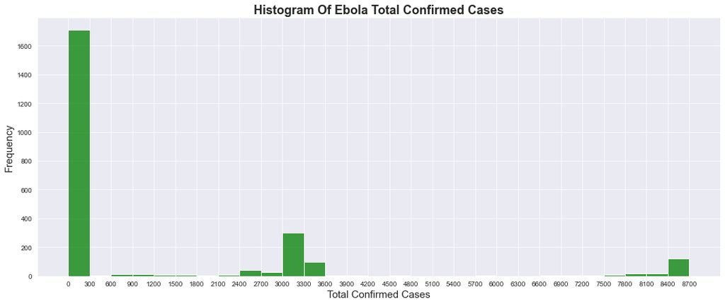

```python
#Exploring the variable 'total confirmed cases' further.
bins = np.arange(0, ebola_df['total_confirmed_cases'].max()+200, 300)
myhist(ebola_df, 'total_confirmed_cases', bins = bins)
plt.xticks(np.arange(0, ebola_df['total_confirmed_cases'].max()+200, 300));
```

Comparing this distribution with the first one, it is clear that at least 1700 values fall between '0-300'. Other values are spread across the rest of the bars in the histogram. However, it is unclear whether there are values that fall within 3600-7500. We might get a clearer picture if we adjust the values on the y-axis.

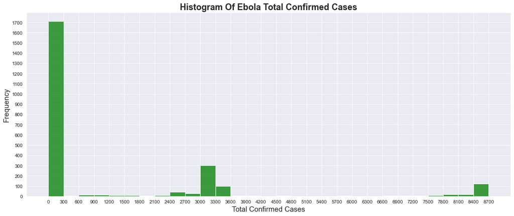

```python
#Exploring the variable 'total confirmed cases' further.
bins = np.arange(0, ebola_df['total_confirmed_cases'].max()+200, 300)
myhist(ebola_df, 'total_confirmed_cases', bins = bins)
plt.xticks(bins);
plt.yticks(np.arange(0, 1800, 100));
```

This chart is the same as the previous one. No values fall between 3600-7500. The typical number of confirmed cases in the countries on most days is 0-300. The values fell in the bars beyond 7500 are not many and suggest a period where some countries experienced a rapid spread of the virus. Let's look to find these instances.

```python
#Where total confirmed cases is equal or higher than 7500
greater_ca= ebola_df.loc[ebola_df['total_confirmed_cases'] >= 7500]

greater_ca
```

|  | date | country | total_confirmed_cases | total_suspected_cases | total_probable_cases | total_confirmed_probable_suspected_cases | total_confirmed_deaths | total_suspected_deaths | total_probable_deaths | total_confirmed_probable_suspected_deaths | year | month_name | monthyear | case_fatality_rate | total_death_category |
| --- | --- | --- | --- | --- | --- | --- | --- | --- | --- | --- | --- | --- | --- | --- | --- |
| 1556 | 2015-01-05 | Sierra Leone | 7570.0 | 1915.0 | 287.0 | 9772.0 | 2549.0 | 158.0 | 208.0 | 2915 | 2015 | January | January 2015 | 33.7 | very_high |
| 1557 | 2015-01-06 | Sierra Leone | 7602.0 | 1819.0 | 287.0 | 9780.0 | 2577.0 | 158.0 | 208.0 | 2943 | 2015 | January | January 2015 | 33.9 | very_high |
| 1558 | 2015-01-07 | Sierra Leone | 7602.0 | 1819.0 | 287.0 | 9780.0 | 2577.0 | 158.0 | 208.0 | 2943 | 2015 | January | January 2015 | 33.9 | very_high |
| 1559 | 2015-01-08 | Sierra Leone | 7759.0 | 1984.0 | 287.0 | 10030.0 | 2611.0 | 158.0 | 208.0 | 2977 | 2015 | January | January 2015 | 33.7 | very_high |
| 1560 | 2015-01-09 | Sierra Leone | 7759.0 | 1984.0 | 287.0 | 10030.0 | 2611.0 | 158.0 | 208.0 | 2977 | 2015 | January | January 2015 | 33.7 | very_high |
| ... | ... | ... | ... | ... | ... | ... | ... | ... | ... | ... | ... | ... | ... | ... | ... |
| 1771 | 2015-12-17 | Sierra Leone | 8704.0 | 5131.0 | 287.0 | 14122.0 | 3589.0 | 158.0 | 208.0 | 3955 | 2015 | December | December 2015 | 41.2 | very_high |
| 1772 | 2015-12-22 | Sierra Leone | 8704.0 | 5131.0 | 287.0 | 14122.0 | 3589.0 | 158.0 | 208.0 | 3955 | 2015 | December | December 2015 | 41.2 | very_high |
| 1773 | 2015-12-23 | Sierra Leone | 8704.0 | 5131.0 | 287.0 | 14122.0 | 3589.0 | 158.0 | 208.0 | 3955 | 2015 | December | December 2015 | 41.2 | very_high |
| 1774 | 2015-12-29 | Sierra Leone | 8704.0 | 5131.0 | 287.0 | 14122.0 | 3589.0 | 158.0 | 208.0 | 3955 | 2015 | December | December 2015 | 41.2 | very_high |
| 1775 | 2016-03-23 | Sierra Leone | 8704.0 | 5131.0 | 287.0 | 14122.0 | 3589.0 | 158.0 | 208.0 | 3955 | 2016 | March | March 2016 | 41.2 | very_high |

220 rows × 15 columns

There are 220 instances where the values of confirmed cases exceed 7500. This explains the reason for the significant cluster of values at the end of the axis.

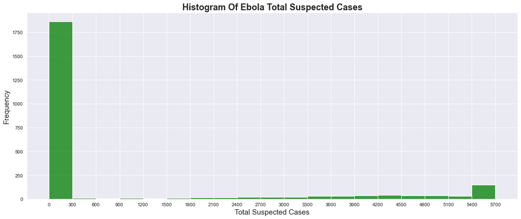

```python
# What is the distribution of total suspected cases?
bins = np.arange(0, ebola_df['total_suspected_cases'].max()+200, 300)
myhist(ebola_df, 'total_suspected_cases', bins = bins)
plt.xticks(bins);
```

There is a cluster of values in the 0-300 bar and then a spread across the rest of the bars. The gradual rise in the number of suspected Ebola cases might have occurred as the days went by in the outbreak.

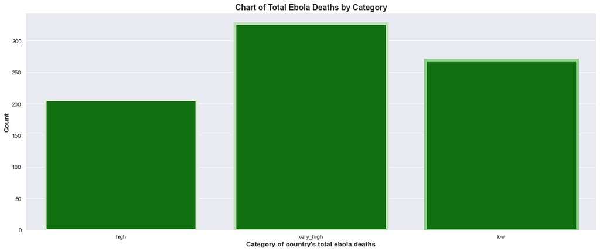

```python
#Plot of the ordinal variable 'total_death_category'
plt.figure(figsize =(18, 7))
sb.countplot(data = ebola_df, x = 'total_death_category', color = 'green', linewidth = 5 , edgecolor = sb.color_palette("Greens"));
plt.xlabel('Category of country\'s total ebola deaths', fontsize = 12, weight = "bold")
plt.ylabel('Count', fontsize = 12, weight = "bold")
plt.title('Chart of Total Ebola Deaths by Category', fontsize =14, weight = "bold");
```

### Discuss the distribution(s) of your variable(s) of interest. Were there any unusual points? Did you need to perform any transformations?

> The variable 'total_confirmed_deaths' had a wide range of values, with a minimum value of 0. After plotting the variable using smaller bin sizes, the number of confirmed deaths from Ebola fell largely between 0–200. There were also other smaller peaks that occurred between 2000-2200 and 3400-3600.

> There was the incidence of a value occurring after 3600, this was explored further to see whether there was a reason for it.

> For the second variable of interest 'total_probable_cases', the number of probable cases each was mostly between 0-200. This is similar to the total confirmed deaths except that the next bar where most values fell into is 200-400.

### Of the features you investigated, were there any unusual distributions? Did you perform any operations on the data to tidy, adjust, or change the form of the data? If so, why did you do this?

> Total confirmed cases values that fell in extreme bars after a wide gap. This was examined and explored further to reveal that these high numbers of confirmed Ebola cases occurred between January 2015- March 2016 in Sierra Leone only. Other features investigated had no unusual points.

## Bivariate Exploration

```python
#creating scatterplots function for bivariate and multipvariate exploration of variables.

def myScatterPlot(ebola_df, xVar, yVar):

    # A simple function created to avoid code repetition. It is to be used in plotting scatter plots within this notebook.
    #inputs : variables to be plotted
    #outputs: scatter plots of dependent variables against independent variable.

    # Plots
    ebola_df.plot(kind= 'scatter', x= xVar, y= yVar, figsize=[19,8], color = 'green');

    # After plotting, tidy up labels
    xVar= xVar.replace("_"," ") #replace _ with a space
    yVar= yVar.replace("_"," ") #replace _ with a space

    # Add title and format it
    plt.title(f'Relationship between {yVar} and {xVar}'.title(), fontsize =14, weight = "bold")

    # Add x label and format it
    plt.xlabel(xVar.title(), fontsize = 12, weight = "bold")


    # Add y label and format it
    plt.ylabel(yVar.title(), fontsize = 12, weight = "bold")
```

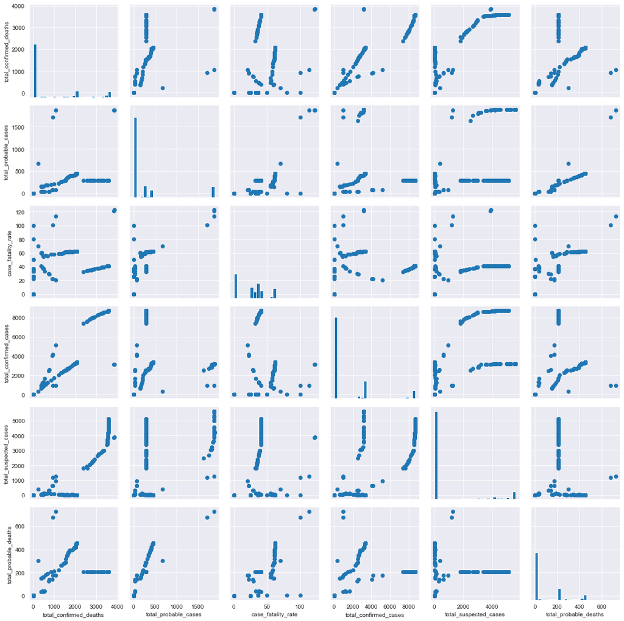

```python
# Matrix with 700 samples.
# Examining the relationship between relevant numeric values using a pairgrid.
# Selecting numeric variables
num_vars = ['total_confirmed_deaths', 'total_probable_cases', 'case_fatality_rate', 'total_confirmed_cases', 'total_suspected_cases', 'total_probable_deaths']

# Choosing random samples from the dataset
samples = np.random.choice(ebola_df.shape[0], 700, replace = False)
eboladf_samp = ebola_df.loc[samples,:]

# Create plot
p = sb.PairGrid(data = eboladf_samp, vars = num_vars, dropna= True);
p = p.map_diag(plt.hist, bins = 25);
p.map_offdiag(plt.scatter);
```

From the pairgrid, total confirmed cases and total suspected cases seem to have a positive linear relationship with total confirmed deaths. This is expected for total confirmed cases because it is likely that as the number of confirmed cases increase, so will the likelihood of the number of deaths. The same cannot be said for total probable cases and total confirmed deaths, the relationship between them is not clear.

A correlation plot will be plotted to see the correlation coefficient of these variables. A scatterplot of confirmed deaths and confirmed cases will be created to get a clearer picture of their relationship.

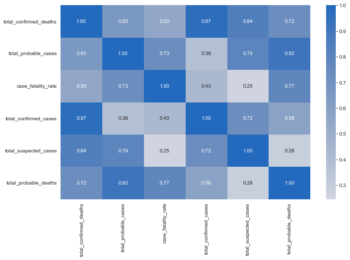

```python
# correlation plot of selected numeric variables
plt.figure(figsize = [11, 7])
sb.heatmap(ebola_df[num_vars].corr(), annot = True, fmt = '.2f',
           cmap = 'vlag_r', center = 0);
```

Unsurprisingly, the correlation coefficient of the confirmed cases and confirmed deaths is 0.97, this is a very stong positive relationship. Therefore, in most cases, as the number of confirmed cases increases, so does the number of deaths.

The correlation between confirmed deaths and probable cases is also positive since r is 0.65.

For total probable cases and total confirmed cases, there is a weak positive relationship(r= 0.38). This is completely unexpected because probable cases are usually those are most expected to become confirmed cases, even more liekly than suspected cases.

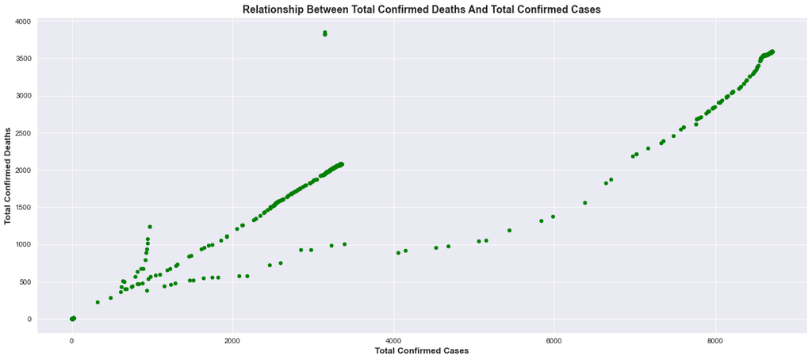

```python
# Exploring the relationship between the main variable of interest 'total_confirmed_deaths' and 'total_confirmed cases'.
# Using a scatterplot
myScatterPlot(ebola_df, 'total_confirmed_cases', 'total_confirmed_deaths')
```

A near perfect positive relationship. Two points appear to be outliers, where total confirmed deaths is approximately 3800 and confirmed cases is approximately 3200.

**Next we will look at number of confirmed Ebola deaths vs Country**

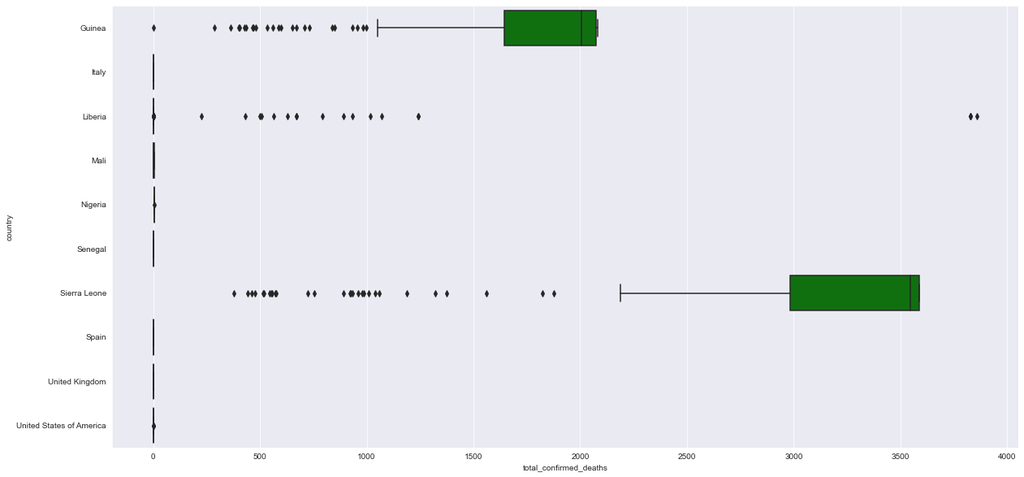

```python
#Confirmed Ebola deaths by country using a boxplot
plt.figure(figsize= (20, 10))
sb.boxplot(data=ebola_df, y='country', x='total_confirmed_deaths', color= 'green');
```

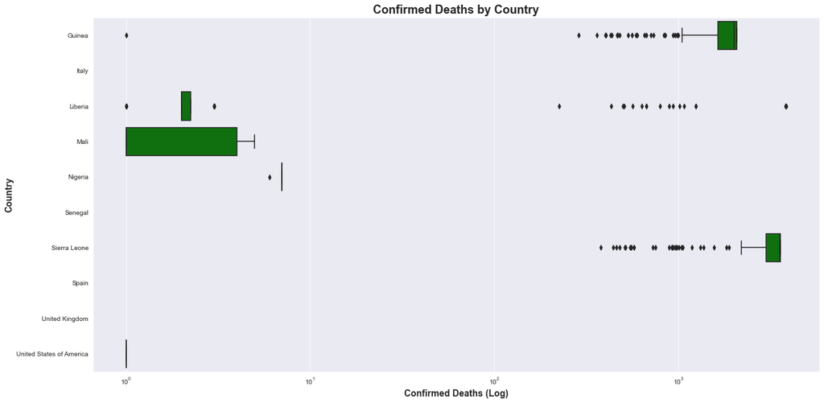

```python
plt.figure(figsize= (20, 10))
sb.boxplot(data=ebola_df, y='country', x='total_confirmed_deaths', color= 'green');
plt.xscale('log')

# Add x label and format it
plt.xlabel('Confirmed Deaths (Log)', fontsize = 14, weight = "bold");

# Add y label and format it
plt.ylabel('Country', fontsize = 14, weight = "bold");

# Add title and format it
plt.title('Confirmed Deaths by Country', fontsize =18, weight = "bold");
```

Ebola death distribution was first plotted on a standard scale and the second on a logarithmic scale. At first the medians and values appeared to be at zero but the logarithmic scale boxplot depicts clearly the position of the median values and the outliers in the confirmed deaths distribution in the countries. It is also noticeable that Italy, Senegal, Spain, and the United Kingdom have not death values.

```python
# Cumulative death in each country for the 2 year duration of the outbreak
ebola_df[['country', 'total_confirmed_deaths', 'total_confirmed_cases']].groupby('country', as_index = False).sum().sort_values('total_confirmed_deaths', ascending = False)
```

|  | country | total_confirmed_deaths | total_confirmed_cases |
| --- | --- | --- | --- |
| 6 | Sierra Leone | 797984.0 | 2041871.0 |
| 0 | Guinea | 461212.0 | 749624.0 |
| 2 | Liberia | 26936.0 | 768736.0 |
| 4 | Nigeria | 1784.0 | 4840.0 |
| 9 | United States of America | 242.0 | 967.0 |
| 3 | Mali | 21.0 | 1658.0 |
| 1 | Italy | 0.0 | 141.0 |
| 5 | Senegal | 0.0 | 254.0 |
| 7 | Spain | 0.0 | 243.0 |
| 8 | United Kingdom | 0.0 | 221.0 |

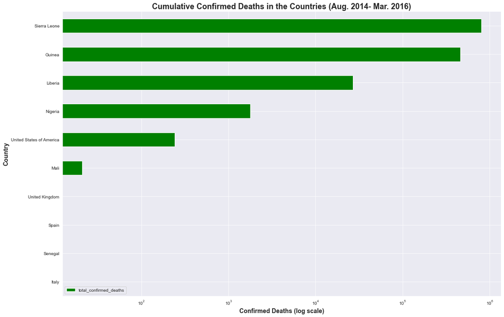

```python
# What is the distribution of cumulative confirmed deaths in each country for the 2-year period?
# Distribution of deaths in the various countries, ordered from highest to lowest.
grouped = ebola_df[['total_confirmed_deaths', 'country', 'date']].groupby('country').sum()
grouped = grouped.sort_values(by = ['total_confirmed_deaths'], ascending = True)

# Plot barchart to display information
grouped.plot.barh(color = 'green', figsize = [18,12]);
plt.xscale('log')

# Add x label and format it
plt.xlabel('Confirmed Deaths (log scale)', fontsize = 14, weight = "bold")

# Add y label and format it
plt.ylabel('Country', fontsize = 14, weight = "bold")

# Add title and format it
plt.title('Cumulative Confirmed Deaths in the Countries (Aug. 2014- Mar. 2016)', fontsize =18, weight = "bold");
```

Sierra Leone, Guinea and Liberia have the highest cumulative confirmed deaths for the duration of the outbreak. The United Kingdom, Spain, Senegal, and Italy have no record of deaths. This confirms what was observed in the boxplot.

```python
# What is the trend in confirmed cases as the outbreak progressed?
#Sorting data to create lineplot of confirmed ebola cases as the outbreak progressed.
# Showing trend of ebola cases in all the days will be overcrowded in one chart. Therefore need to split data into years.

# Confirmed cases in 2014
edf_date = ebola_df.loc[ebola_df['year'] == 2014]

# Confirmed cases in 2015, grouped and sorted by month instead of day to reduce data volume and make plotting easier.
edf_date2 = ebola_df.loc[ebola_df['year'] == 2015]

# Confirmed cases in 2016
edf_date3 = ebola_df.loc[ebola_df['year'] == 2016]
```

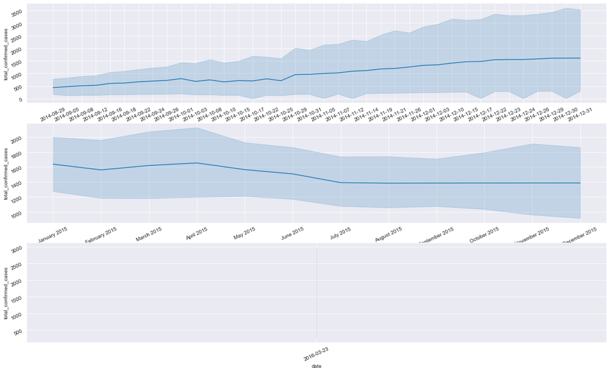

```python
# Trends in confirmed Ebola cases as the days progressed #Line plot

fig, ax = plt.subplots(nrows=3, figsize = [20,12])

ax[0].tick_params(labelrotation = 25)
sb.lineplot(data = edf_date, x= 'date', y= 'total_confirmed_cases', ax= ax[0]);

ax[1].tick_params(labelrotation = 25)
sb.lineplot(data = edf_date2, x= 'monthyear', y= 'total_confirmed_cases', ax= ax[1]);

ax[2].tick_params(labelrotation = 25)
sb.lineplot(data = edf_date3, x= 'date', y= 'total_confirmed_cases', ax = ax[2]);
```

There is a consistent rise and fall in the number of confirmed cases across the period. There are not many data points in 2016. There is data for only 23rd March 2016 in the dataset.

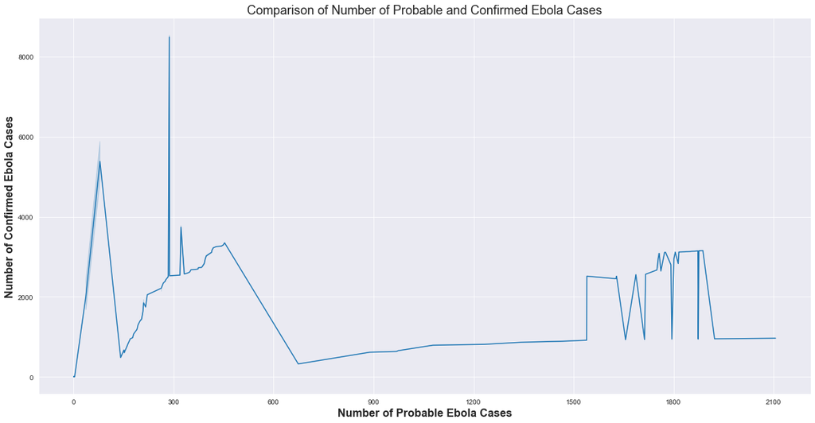

```python
# How do probable and confirmed Ebola cases compare? #line plot
plt.figure(figsize= (20,10))

sb.lineplot(data = ebola_df, x= 'total_probable_cases', y= 'total_confirmed_cases');
plt.xticks(np.arange(0, 2000+300, 300));

#Setting labels/titles for axis
plt.xlabel('Number of Probable Ebola Cases', fontsize = 16, weight = "bold")
plt.ylabel('Number of Confirmed Ebola Cases', fontsize = 16, weight = "bold")

#Adding title of chart and legend for rating values
plt.title('Comparison of Number of Probable and Confirmed Ebola Cases', fontsize=18);
```

Although there were incidents when the number of probable cases and number of confimrmed cases had close values. An increase in the number of probable cases does not suggest there will be an increase in the number of confirmed case. On the contrary, when probable case numbers were low, number of confirmed cases spiked and were found to be higher.

```python
# What is the cumulative number of deaths in each country for the 2 year duration of the outbreak.

# Calculate case fatality rate in each country for the duration of the epidemic.
ebola_tablesum = ebola_df[['country', 'total_confirmed_deaths', 'total_confirmed_cases']].groupby('country', as_index = False).sum().sort_values('total_confirmed_deaths', ascending = False)
ebola_tablesum['case_fatality_overall'] = (ebola_tablesum['total_confirmed_deaths'] / ebola_tablesum['total_confirmed_cases']) * 100
```

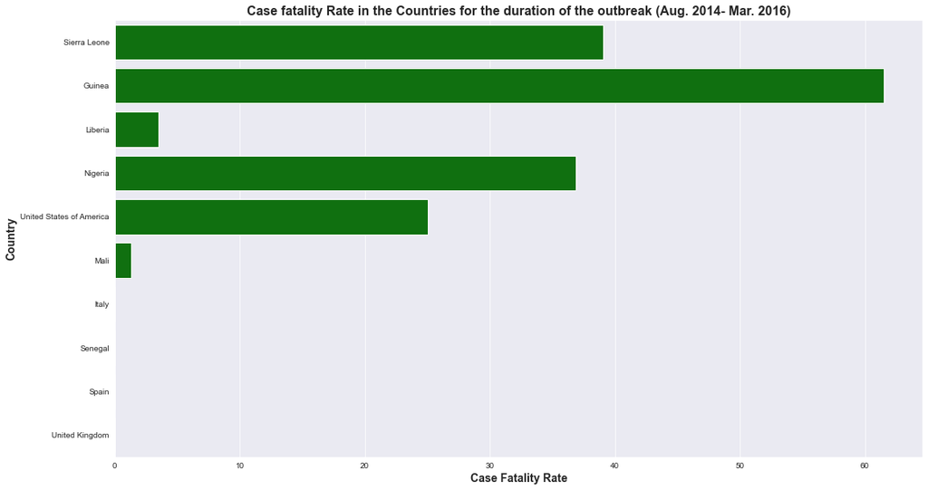

```python
# What is the Case fatality rate in each country for the duration of the outbreak?
# Plot chart
plt.figure(figsize = (18, 10))
sb.barplot(data = ebola_tablesum, y= 'country', x= 'case_fatality_overall', color = 'green');

# Add x label and format it
plt.xlabel('Case Fatality Rate', fontsize = 14, weight = "bold")

# Add y label and format it
plt.ylabel('Country', fontsize = 14, weight = "bold")

# Add title and format it
plt.title('Case fatality Rate in the Countries for the duration of the outbreak (Aug. 2014- Mar. 2016)', fontsize =16, weight = "bold");
```

The severity of the epidemic was the highest in Guinea compared to the other countries. Even though Sierra Leone had the greatest number of confirmed deaths and cases, it's case fatality rate was not as high as in Guinea. One would expect Liberia to have the third highest case fatality rate but this is not case. Nigeria has the third highest case fatality rate. Case fatality rate is a measure of disease severity.

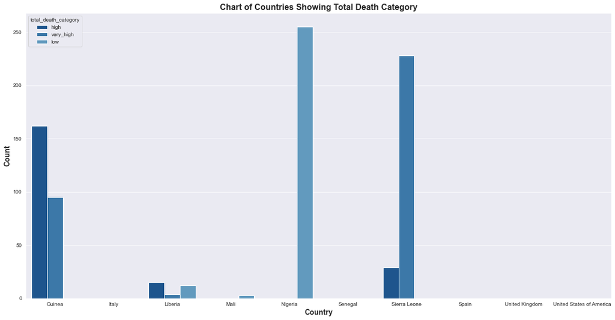

```python
# Plot clustered bar chart of countries and total death category
# Based on death category for each day during the outbreak, no aggregation applied.
plt.figure(figsize=(20, 10))

sb.countplot(data = ebola_df, x = 'country', hue = 'total_death_category', palette = sb.color_palette("Blues_r"));

# Add x label and format it
plt.xlabel('Country', fontsize = 14, weight = "bold")

# Add y label and format it
plt.ylabel('Count', fontsize = 14, weight = "bold")

# Add title and format it
plt.title('Chart of Countries Showing Total Death Category', fontsize =16, weight = "bold");
```

### Talk about some of the relationships you observed in this part of the investigation. How did the feature(s) of interest vary with other features in the dataset?

> Confirmed deaths had a near perfect relationship with confirmed cases. In other words, at least 90% of the time, as the number of cases increased so did the number of deaths. However, the relationship between confirmed deaths and confirmed probable cases was not as strong(r = 0.65) though positive. There was also a strong positive correlation between confirmed deaths, total suspected cases and total probable deaths.

> Contrary to expectations, there was a weak positive relationship between the number of probable cases and the number of confirmed cases. An increase in the number of probable cases did not suggest there will be an increase in the number of confirmed cases.

## Multivariate Exploration

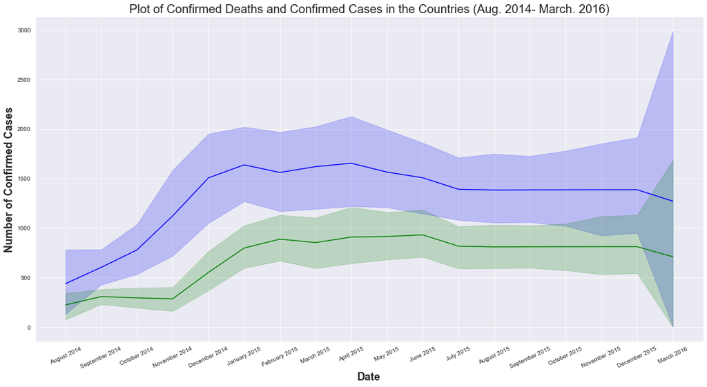

```python
# Finally examine the spread of number of confirmed deaths and confirmed cases in the 2 year outbreak
plt.figure(figsize= (20,10))

sb.lineplot(data = ebola_df, x= 'monthyear', y= 'total_confirmed_cases', color = 'blue');
sb.lineplot(data= ebola_df, x= 'monthyear', y= 'total_confirmed_deaths', color= 'green');
plt.xticks(rotation = 25);

#Setting labels/titles for axis
plt.xlabel('Date', fontsize = 18, weight = "bold")
plt.ylabel('Number of Confirmed Cases', fontsize = 18, weight = "bold")

#Adding title of chart and legend for rating values
plt.title('Plot of Confirmed Deaths and Confirmed Cases in the Countries (Aug. 2014- March. 2016)', fontsize=20);
```

Number of confirmed deaths also showed a similar pattern with the number of confirmed cases. This is expected since they are very strongly correlated.

Let's explore the number of confirmed deaths and confirmed cases in the first year of the outbreak.

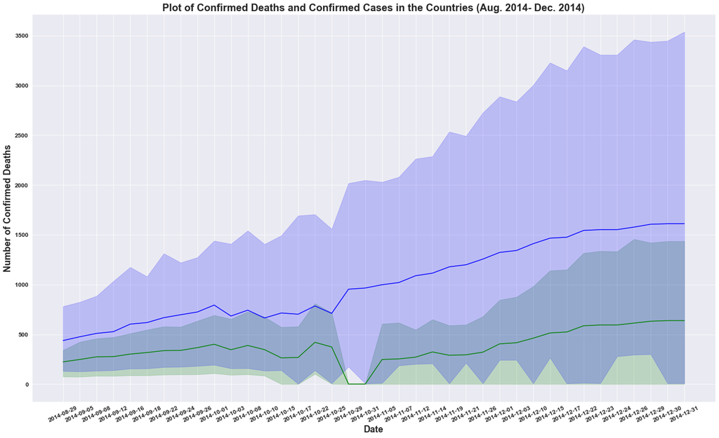

```python
#Time series plot of confirmed deaths and confirmed cases in 2014. This gives an idea of outbreak progression at the commencment (first year) of the epidemic.
#2014
plt.figure(figsize= (24,14))

sb.lineplot(data = edf_date, x= 'date', y= 'total_confirmed_deaths', color ='green');
sb.lineplot(data= edf_date, x= 'date', y = 'total_confirmed_cases', color = 'blue');
plt.xticks(rotation = 25, weight = 'bold', fontsize = 12);
plt.yticks(rotation = 0, weight = 'bold', fontsize = 12);

#Setting labels/titles for axis
plt.xlabel('Date', fontsize = 18, weight = "bold");
plt.ylabel('Number of Confirmed Deaths', fontsize = 18, weight = "bold");


# Add title
plt.title('Plot of Confirmed Deaths and Confirmed Cases in the Countries (Aug. 2014- Dec. 2014)', fontsize = 20, weight = "bold");
```

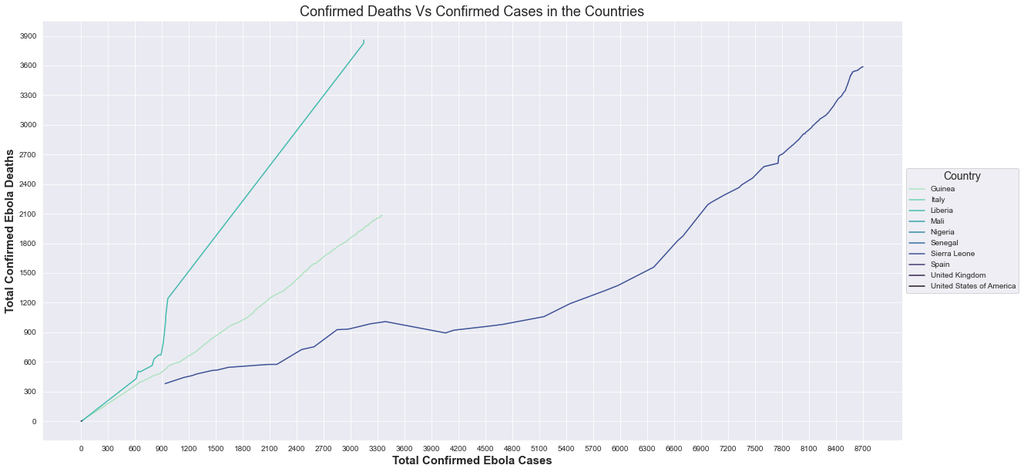

```python
# How do confirmed deaths and confirmed Ebola cases compares in the different countries? #line plot
#three variables: confirmed deaths, confirmed cases, and country

plt.figure(figsize= (20,10))
sb.lineplot(data = ebola_df, x= 'total_confirmed_cases', y= 'total_confirmed_deaths', hue = 'country', palette = sb.color_palette("mako_r", 10));
plt.xticks(np.arange(0, ebola_df['total_confirmed_cases'].max()+ 200, 300));
plt.yticks(np.arange(0, ebola_df['total_confirmed_deaths'].max() + 300, 300));

#Setting labels/titles for axis
plt.xlabel('Total Confirmed Ebola Cases', fontsize = 15, weight = "bold")
plt.ylabel('Total Confirmed Ebola Deaths', fontsize = 15, weight = "bold")

#Adding title of chart and legend for rating values
plt.title('Confirmed Deaths Vs Confirmed Cases in the Countries', fontsize=18);

#Format legend
plt.legend(loc='center left', bbox_to_anchor=(1, 0.5),
           title="Country", title_fontsize = 14);
```

Plotting on the standard scale shows data points for only three countries. Let's plot this on a log scale and see whether there will be a difference.

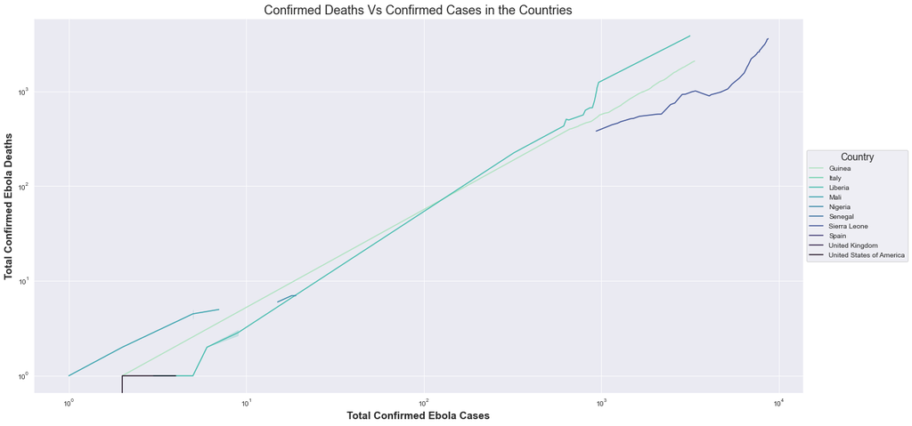

```python
# How do confirmed deaths and confirmed Ebola cases compares in the different countries? #line plot
#three variables: confirmed deaths, confirmed cases, and country

plt.figure(figsize= (20,10))
sb.lineplot(data = ebola_df, x= 'total_confirmed_cases', y= 'total_confirmed_deaths', hue = 'country', palette = sb.color_palette("mako_r", 10));
plt.xscale('log');
plt.yscale('log');

#Setting labels/titles for axis
plt.xlabel('Total Confirmed Ebola Cases', fontsize = 15, weight = "bold")
plt.ylabel('Total Confirmed Ebola Deaths', fontsize = 15, weight = "bold")

#Adding title of chart and legend for rating values
plt.title('Confirmed Deaths Vs Confirmed Cases in the Countries', fontsize=18);

#Format legend
plt.legend(loc='center left', bbox_to_anchor=(1, 0.5),
           title="Country", title_fontsize = 14);
```

More countries are visible in the plot above. There is no associated pattern between the countries' confirmed deaths and confirmed cases.

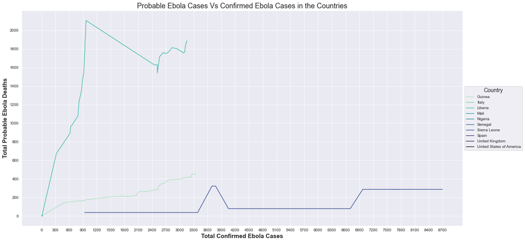

```python
# How do probable and confirmed Ebola cases compares in the different countries? #line plot
#three variables: probable cases, confirmed cases, and country

plt.figure(figsize= (20,10))
sb.lineplot(data = ebola_df, x= 'total_confirmed_cases', y= 'total_probable_cases', hue = 'country', palette = sb.color_palette("mako_r", 10));
plt.xticks(np.arange(0, ebola_df['total_confirmed_cases'].max()+ 200, 300));
plt.yticks(np.arange(0, 2000 + 200, 200));

#Setting labels/titles for axis
plt.xlabel('Total Confirmed Ebola Cases', fontsize = 15, weight = "bold")
plt.ylabel('Total Probable Ebola Deaths', fontsize = 15, weight = "bold")

#Adding title of chart and legend for rating values
plt.title('Probable Ebola Cases Vs Confirmed Ebola Cases in the Countries', fontsize=18);

#Format legend
plt.legend(loc='center left', bbox_to_anchor=(1, 0.5),
           title="Country", title_fontsize = 14);
```

For Guinea, as the number of probable cases increased, so did the number of confirmed. Sierra Leone maintained it line, only rising at two different. Though, the number of probable cases remained at almost the same value, the number of confirmed cases kept rising.

### Talk about some of the relationships you observed in this part of the investigation. Were there features that strengthened each other in terms of looking at your feature(s) of interest?

> The effect of the number of confirmed cases on the number of deaths is confirmed even more in this section when both variables are plotted within the date context. There are no similarities in the pattern of number of confirmed deaths, number of probable cases and number of confirmed cases. Geographical similarities like in the African countries did not seem to make patterns in confirmed cases or probable cases similar.

### Were there any interesting or surprising interactions between features?

> It was surprising to notice that despite the relative closeness of the affected African Countries, there was no apparent similar pattern in the deaths and cases recorded. Of no surprise is the trend of the number of cases in the European countries.

## Conclusions

With the aid of various visualization methods, we examined the Ebola data and statistics recorded for the 2014 outbreak and concluded that the severity of the outbreak was greatest in Guinea, Sierra Leone and Nigeria, respectively putting into consideration their case fatality rate for the duration of the outbreak. It was also great to identify four countries that had the least number of confirmed cases and recorded no deaths. In no particular order, these countries are the United Kindgom, Italy, Spain and Senegal. It might be worthy to commend Liberia because though it had the second largest number of confirmed cases, when compared with the confirmed deaths, the treatment and management of patients was successful.

One of the goals of this investigation was to identify whether there was a relationship between confirmed deaths and confirmed cases. This was noted to be positive, observing that as the number of confirmed cases increased, so did the number of deaths. Contrary to what was initially thought, there was a weak positive relationship between the number of probable cases and the number of confirmed cases.

The World Health Organization(WHO) stated that the average case fatality rate is 50%. Most countries had case fatality rates below this according to the dataset analyzed.